# One-Way ANOVA - Week 5, Lecture 1

Author

Hector Gavilanes

```r
#install.packages(DescTools)
library(tidyverse)
library(gsheet)
library(formattable)
library(DescTools) # perform Dunnett Test
```

**An agricultural researcher investigated two new herbicides and their effects on crop yields of tomatoes, which can be demolished by the [tomato hornworm](https://extension.umn.edu/yard-and-garden-insects/tomato-hornworms) in mere hours. There were three areas for the experiment: an area for herbicide A, an area for herbicide B, and an area for no herbicide at all (control). At the end of the growing season, the yields (in bushels per acre) were measured and are available in the following [Google Sheet](https://docs.google.com/spreadsheets/d/1CFyuuWy-4YmVU3wkYuC8Uf3xW3qkpCnpF468NjBAhbY/edit#gid=0).**

```r
# clear environment
rm(list = ls())

# extract data
data <- as_tibble(gsheet2tbl("https://docs.google.com/spreadsheets/d/1CFyuuWy-4YmVU3wkYuC8Uf3xW3qkpCnpF468NjBAhbY/edit#gid=0"))

# transform data
clean_data <- data %>%
  # delete empty rows
  drop_na()
# pivot to long data
long_data <- clean_data %>%
  pivot_longer(cols = c("Herbicide1", "Herbicide2", "Control"),
               names_to = "Herbicide_groups",
               values_to = "Results")

# ---Colors---
custom_green = "#7FBD32"
custom_purple = "#700CBC"
custom_orange = "#FB8604"

# ***FUNCTIONS***
# f01 // change default table format
change_table_format <- function(table_name){
  formattable(
  table_name, align =c("c","c", "c"),
  list(area() ~ color_text("black", "#555888"))
  )
}
# f02 // get confidence intervals for each group
get_ci <- function(df, category, continue_variable){
  ci <- df %>%
    group_by(!! sym(category)) %>%
    summarise(
      ci_lower = t.test(!! sym(continue_variable), conf.level = 0.95)$conf.int[1],
      ci_upper = t.test(!! sym(continue_variable), conf.level = 0.95)$conf.int[2]
    )
  return(ci)
}
# f03 // get mean, confidence intervals for each group
get_mean_ci <- function(df, category, continue_variable){
  ci <- df %>%
    group_by(!! sym(category)) %>%
    summarise(
      mean = mean(!! sym(continue_variable)),
      ci_lower = t.test(!! sym(continue_variable), conf.level = 0.95)$conf.int[1],
      ci_upper = t.test(!! sym(continue_variable), conf.level = 0.95)$conf.int[2]
    )
  return(ci)
}
```

#### 1. Construct the 95% confidence interval for the average yield for each group (A, B, control).

```r
# print CI table for the average yield for each group
ci <- get_ci(long_data, 'Herbicide_groups', 'Results')
change_table_format(ci)
```

| Herbicide_groups | ci_lower | ci_upper |
| --- | --- | --- |
| Control | 84.66827 | 90.17840 |
| Herbicide1 | 82.12035 | 88.43299 |
| Herbicide2 | 88.33621 | 92.15712 |

#### 2. Challenge! Construct a graph to display all confidence intervals.

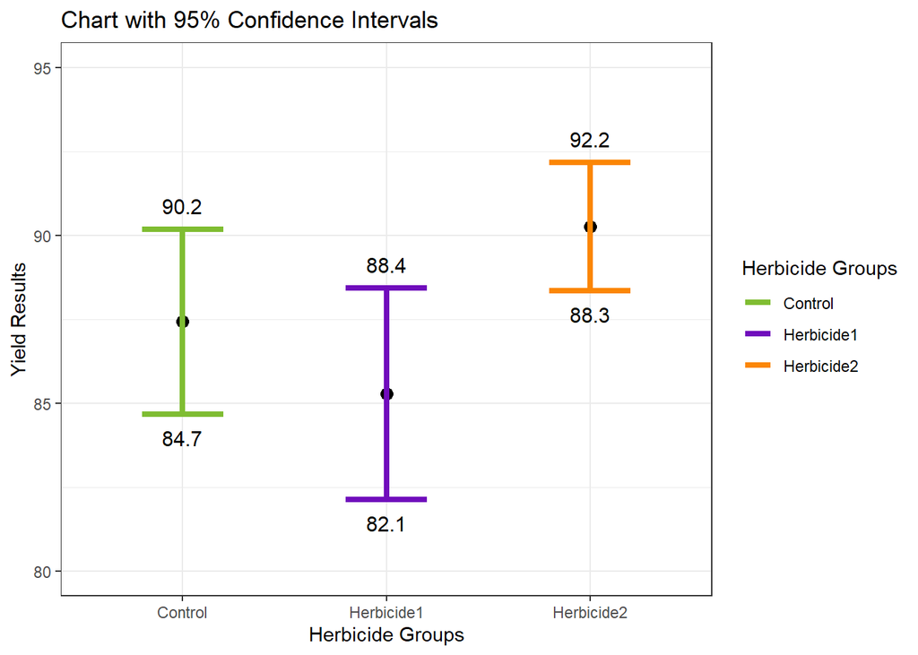

```r
# get mean, CI for each group
mean_ci <- get_mean_ci(long_data, 'Herbicide_groups', 'Results')

# Plot Confidence Intervals
ggplot(mean_ci, aes(x = Herbicide_groups, y = mean))+
  # geom_line(aes(x = Herbicide_groups, y = mean))+
  geom_point(aes(x = Herbicide_groups, y = mean), color = "black", size = 3)+
  scale_color_manual(name = "Herbicide Groups", values=c(custom_green, custom_purple, custom_orange))+
  geom_errorbar(aes(x = Herbicide_groups, ymin = ci_lower, ymax = ci_upper,
                    color = factor(Herbicide_groups)), size = 1.5, width = 0.4)+
  geom_text(aes(y = ci_lower, label = round(ci_lower,1)), size = 4, vjust = 2, color = "black")+
  geom_text(aes(y = ci_upper, label = round(ci_upper,1)), size = 4, vjust = -1, color = "black")+
  labs(title = "Chart with 95% Confidence Intervals")+
  labs(x="Herbicide Groups", y="Yield Results")+
  theme(legend.position="none")+
  ylim(80, 95)+
  theme_bw()
```

#### 3. Challenge! Why should we be cautious when using the individual CIs found in Q1 and displayed in Q2 to directly compare the three groups?

Visually, the CI overlapping method fails to reject the null hypothesis more frequently than the corresponding hypothesis test. Using this method decreases the statistical power of an adequate assessment, potentially causing to miss differences.

#### 4. Use the appropriate hypothesis test to show that there is a difference in the average yield between the three groups. Test at the $\alpha=0.05$ level.

```r
# one-way ANOVA Hypothesis test
module_data_anova <- aov(long_data$Results ~ long_data$Herbicide_groups)
summary(module_data_anova)
```

```
                           Df Sum Sq Mean Sq F value Pr(>F)
long_data$Herbicide_groups  2    373  186.40   3.677 0.0293 *
Residuals                  87   4410   50.69
---
Signif. codes:  0 '***' 0.001 '**' 0.01 '*' 0.05 '.' 0.1 ' ' 1
```

### Hypothesis

- $H_0$: $\mu Control = \mu HerbicideA\ = \mu HerbicideB$
- $H_1$: at least one is different

### Test Statistic

- $F_0 = 3.677$

### p-Value

- $p = 0.0293$

## Conclusion

Reject $H_0$ at the $\alpha$=0.05 level. There is sufficient evidence to suggest that there is a difference in the average yield between the three groups.

#### 5. Construct and test the following contrasts for the following comparisons:

##### a. Herbicide A vs. Herbicide B. Test at the $\alpha=0.05$ level.

```r
# Post-hoc Testing: Linear Contrasts
# check the order of the groups
long_data$Herbicide_groups <- as.factor(long_data$Herbicide_groups)
contrasts(long_data$Herbicide_groups)
```

```
           Herbicide1 Herbicide2
Control             0          0
Herbicide1          1          0
Herbicide2          0          1
```

```r
# adjust the alpha level
# assigning specific values to the matrix depending on grouping
contrasts(long_data$Herbicide_groups) <- cbind(c(0, -1, 1),
                                               c(-1, 0.5, 0.5))
```

After the Order Verification Process, proceed with the specific linear contrast.

```r
# ANOVA test: A vs B
m1 <- aov(Results ~ Herbicide_groups,
          data = long_data)
summary.aov(m1, split=list(Herbicide_groups=list("A vs. B"=1)))
```

```
                            Df Sum Sq Mean Sq F value  Pr(>F)
Herbicide_groups             2    373   186.4   3.677 0.02930 *
  Herbicide_groups: A vs. B  1    371   370.5   7.310 0.00825 **
Residuals                   87   4410    50.7
---
Signif. codes:  0 '***' 0.001 '**' 0.01 '*' 0.05 '.' 0.1 ' ' 1
```

### Hypothesis - Linear Contrasts

- $H_0$: $\mu HerbicideA\ = \mu HerbicideB$
- $H_1$: $\mu HerbicideA\ \ne \mu HerbicideB$

### Test Statistic

- $F_0 = 7.310$

### p-Value

- $p = 0.00825$

## Conclusion

Reject $H_0$ at the $\alpha$=0.05 ($\alpha_B$ = 0.025) level. There is sufficient evidence to suggest that there is a difference in the average yield between Herbicide A vs Herbicide B groups.

Moreover, a Paiwise t-test with Bonferroni Correction has been performed.

```r
pairwise.t.test(long_data$Results, long_data$Herbicide_groups, p.adjust.method = "bonferroni")
```

```
    Pairwise comparisons using t tests with pooled SD

data:  long_data$Results and long_data$Herbicide_groups

           Control Herbicide1
Herbicide1 0.738   -
Herbicide2 0.385   0.025

P value adjustment method: bonferroni
```

The only significant difference with a p-value = 0.025 is between Herbicide A vs Herbicide B .

##### b. Herbicide A and Herbicide B vs. Control. Test at the $\alpha=0.05$ level.

```r
# ANOVA test: A + B vs Control
m2 <- aov(Results ~ Herbicide_groups,
          data = long_data)
summary.aov(m2, split=list(Herbicide_groups=list("A + B vs. Control."=2)))
```

```
                                       Df Sum Sq Mean Sq F value Pr(>F)
Herbicide_groups                        2    373  186.40   3.677 0.0293 *
  Herbicide_groups: A + B vs. Control.  1      2    2.29   0.045 0.8322
Residuals                              87   4410   50.69
---
Signif. codes:  0 '***' 0.001 '**' 0.01 '*' 0.05 '.' 0.1 ' ' 1
```

### Hypothesis - Linear Contrasts

- $H_0$: $\mu HerbicideA\ + \mu HerbicideB\ = \mu Control$
- $H_1$: $\mu HerbicideA\ + \mu HerbicideB\ \ne \mu Control$

### Test Statistic

- $F_0 = 0.045$

### p-Value

- $p = 0.8322$

## Conclusion

Keep $H_0$ at the $\alpha$=0.05 ($\alpha_B$ = 0.025) level. There is not sufficient evidence to suggest that the average yield between the Herbicide A and Herbicide B groups are different from the control group.

#### 6. Use the appropriate posthoc test to perform all pairwise comparisons of yield. Test at the $\alpha=0.05$ level.

```r
TukeyHSD(m1)
```

```
  Tukey multiple comparisons of means
    95% family-wise confidence level

Fit: aov(formula = Results ~ Herbicide_groups, data = long_data)

$Herbicide_groups
                           diff        lwr      upr     p adj
Herbicide1-Control    -2.146667 -6.5299533 2.236620 0.4755346
Herbicide2-Control     2.823333 -1.5599533 7.206620 0.2793168
Herbicide2-Herbicide1  4.970000  0.5867134 9.353287 0.0222477
```

There is a difference between Herbicide A and B (p = 0.022).

#### 7. Use the appropriate posthoc test to only compare the individual herbicides to the control. Test at the $\alpha=0.05$ level.

```r
DunnettTest(x = long_data$Results,
            g = long_data$Herbicide_groups,
            control = "Control")
```

```
  Dunnett's test for comparing several treatments with a control :
    95% family-wise confidence level

$Control
                        diff    lwr.ci   upr.ci   pval
Herbicide1-Control -2.146667 -6.280237 1.986904 0.4012
Herbicide2-Control  2.823333 -1.310237 6.956904 0.2209

---
Signif. codes:  0 '***' 0.001 '**' 0.01 '*' 0.05 '.' 0.1 ' ' 1
```

No significant difference against the control group.